# BAN 4600 Final Project

# Hotel Booking Analysis & Strategies

## Team Members: Lina Duarte, Rubina Pradhan, Rachel Prathiba John, Vinay Karthick Jeyabalakrishnan and Prathiksha Bojamma Paleyada Thimmaiah

# Dataset Description:

Importing all the necessary libraries:

```python
import pandas as pd
import numpy as np
import matplotlib.pyplot as plt
import seaborn as sns
import statsmodels.formula.api as smf
import statsmodels.api as sm
import patsy
import matplotlib.ticker as ticker
%matplotlib notebook
```

Importing the main Dataset:

```python
data = "D:/Rubina/Clark Univeristy/Semester 1/STAT 4600-02 (Intermed Stats Model Analytics)/PROJECT/hotel_bookings.csv"
df = pd.read_csv(data)
```

Displaying the raw format of Hotel Booking Dataset:

```python
df.head()
```

|  | hotel | is_canceled | lead_time | arrival_date_year | arrival_date_month | arrival_date_week_number | arrival_date_day_of_month | stays_in_weekend_nights | stays_in_week_nights | adults | ... | deposit_type | agent | company | days_in_waiting_list | customer_type | adr | required_car_parking_spaces | total_of_special_requests | reservation_status | reservation_status_date |
| --- | --- | --- | --- | --- | --- | --- | --- | --- | --- | --- | --- | --- | --- | --- | --- | --- | --- | --- | --- | --- | --- |
| 0 | Resort Hotel | 0 | 342 | 2015 | July | 27 | 1 | 0 | 0 | 2 | ... | No Deposit | NaN | NaN | 0 | Transient | 0.0 | 0 | 0 | Check-Out | 2015-07-01 |
| 1 | Resort Hotel | 0 | 737 | 2015 | July | 27 | 1 | 0 | 0 | 2 | ... | No Deposit | NaN | NaN | 0 | Transient | 0.0 | 0 | 0 | Check-Out | 2015-07-01 |
| 2 | Resort Hotel | 0 | 7 | 2015 | July | 27 | 1 | 0 | 1 | 1 | ... | No Deposit | NaN | NaN | 0 | Transient | 75.0 | 0 | 0 | Check-Out | 2015-07-02 |
| 3 | Resort Hotel | 0 | 13 | 2015 | July | 27 | 1 | 0 | 1 | 1 | ... | No Deposit | 304.0 | NaN | 0 | Transient | 75.0 | 0 | 0 | Check-Out | 2015-07-02 |
| 4 | Resort Hotel | 0 | 14 | 2015 | July | 27 | 1 | 0 | 2 | 2 | ... | No Deposit | 240.0 | NaN | 0 | Transient | 98.0 | 0 | 1 | Check-Out | 2015-07-03 |

5 rows × 32 columns

Note: The above dataset contains 119390 rows and 32 columns which comprises of hotel type, booking and cancellation, lead time, arrival date year, stay in weekends and nights, number of adults, children and babies, deposit type, agent, company, customer type, adr, required car parking spaces, special guests and reservation details.

Locating null values in the dataset:

```python
print(hotel_df.isnull())
```

[output not shown]

[output cut: 64 more lines]

Note: The main dataset includes 119390 rows and 32 columns. The raw format of Hotel Booking data does conatin null/ missing values.

# Cleaning and Processing:

Data Cleaning: "the process of preparing data for analysis by removing or modifying data that is incorrect, incomplete, irrelevant, duplicated, or improperly formatted."

Data processing:"data is collected and translated into usable information."

Data Cleaning of Hotel Booking requires a number of unwanted columns to be drop down. Removing the NA values and unwanted columns from the main dataset.

```python
hotel_df=df.drop(['reserved_room_type','meal','agent','required_car_parking_spaces','days_in_waiting_list','total_of_special_requests','reservation_status','reservation_status_date'], axis=1)
hotel_df.head()
```

|  | hotel | is_canceled | lead_time | arrival_date_year | arrival_date_month | arrival_date_week_number | arrival_date_day_of_month | stays_in_weekend_nights | stays_in_week_nights | adults | ... | distribution_channel | is_repeated_guest | previous_cancellations | previous_bookings_not_canceled | assigned_room_type | booking_changes | deposit_type | company | customer_type | adr |
| --- | --- | --- | --- | --- | --- | --- | --- | --- | --- | --- | --- | --- | --- | --- | --- | --- | --- | --- | --- | --- | --- |
| 0 | Resort Hotel | 0 | 342 | 2015 | July | 27 | 1 | 0 | 0 | 2 | ... | Direct | 0 | 0 | 0 | C | 3 | No Deposit | NaN | Transient | 0.0 |
| 1 | Resort Hotel | 0 | 737 | 2015 | July | 27 | 1 | 0 | 0 | 2 | ... | Direct | 0 | 0 | 0 | C | 4 | No Deposit | NaN | Transient | 0.0 |
| 2 | Resort Hotel | 0 | 7 | 2015 | July | 27 | 1 | 0 | 1 | 1 | ... | Direct | 0 | 0 | 0 | C | 0 | No Deposit | NaN | Transient | 75.0 |
| 3 | Resort Hotel | 0 | 13 | 2015 | July | 27 | 1 | 0 | 1 | 1 | ... | Corporate | 0 | 0 | 0 | A | 0 | No Deposit | NaN | Transient | 75.0 |
| 4 | Resort Hotel | 0 | 14 | 2015 | July | 27 | 1 | 0 | 2 | 2 | ... | TA/TO | 0 | 0 | 0 | A | 0 | No Deposit | NaN | Transient | 98.0 |

5 rows × 24 columns

# Index

| Index No. |  | Columns |  | Data Type |
| --- | --- | --- | --- | --- |
| 1 |  | hotel |  | object |
| 2 |  | is_canceled |  | int64 |
| 3 |  | lead_time |  | int64 |
| 4 |  | arrival_date_year |  | int64 |
| 5 |  | arrival_date_month |  | object |
| 6 |  | arrival_date_week_number |  | int64 |
| 7 |  | arrival_date_day_of_month |  | int64 |
| 8 |  | stays_in_weekend_nights |  | int64 |
| 9 |  | stays_in_week_nights |  | int64 |
| 10 |  | adults |  | int64 |
| 11 |  | children |  | float64 |
| 12 |  | babies |  | int64 |
| 13 |  | country |  | object |
| 14 |  | market_segment |  | object |
| 15 |  | distribution_channel |  | object |
| 16 |  | is_repeated_guest |  | int64 |
| 17 |  | previous_cancellations |  | int64 |
| 18 |  | previous_bookings_not_canceled |  | int64 |
| 19 |  | assigned_room_type |  | object |
| 20 |  | booking_changes |  | int64 |
| 21 |  | deposit_type |  | object |
| 22 |  | company |  | float64 |
| 23 |  | customer_type |  | object |
| 24 |  | adr |  | float64 |

```python
hotel_df.isnull().sum().sort_values(ascending=False)[:10]
```

```
company                           112593
country                              488
children                               4
market_segment                         0
customer_type                          0
deposit_type                           0
booking_changes                        0
assigned_room_type                     0
previous_bookings_not_canceled         0
previous_cancellations                 0
dtype: int64
```

# 1. Which type of Hotel is most prefered? City Hotel or Resort Hotel?

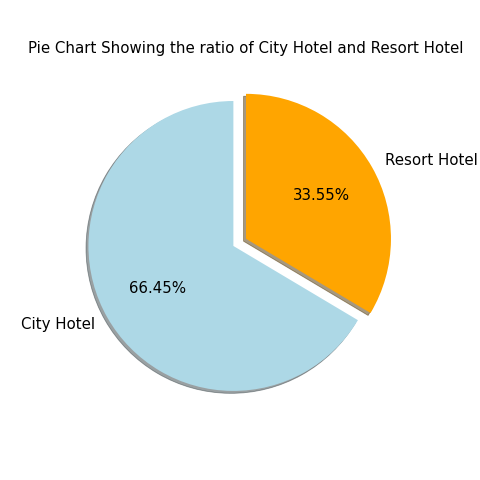

```python
plt.rcParams['figure.figsize']=8,8
labels=hotel_df['hotel'].value_counts().index.tolist()
sizes=hotel_df['hotel'].value_counts().tolist()
colors=['lightblue','orange']
explode=(0.1, 0)
plt.title("Pie Chart Showing the ratio of City Hotel and Resort Hotel", fontsize=18)
plt.pie(sizes,labels=labels,colors=colors,explode=explode,autopct='%1.2f%%',shadow= True, startangle=90, textprops={'fontsize':18})
plt.show()
```

# 2. Total number of Cancelation in City Hotel and Resort Hotel

```python
hotel_df.groupby(['arrival_date_year'])['is_canceled'].mean()
```

```
arrival_date_year
2015    0.370158
2016    0.358633
2017    0.386979
Name: is_canceled, dtype: float64
```

From the above code, it can be indicated that the cancellation rate was highest in the year 2017 and lowest in the year 2016.

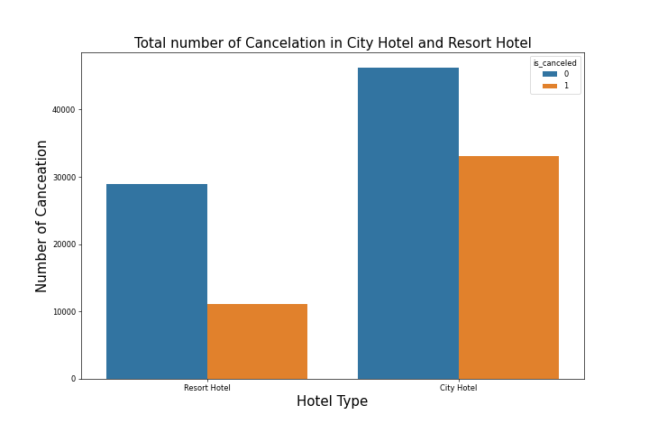

```python
plt.figure(figsize=(12,8))

sns.countplot(x='hotel',hue='is_canceled', data=hotel_df)
plt.title("Total number of Cancelation in City Hotel and Resort Hotel", fontsize=18)
plt.xlabel("Hotel Type", fontsize=18)
plt.ylabel("Number of Canceation", fontsize=18)
plt.show()
```

Explaination: This graph depicts the number of cancellations for city and resort hotels. From this graph, we can see that the number of cancellations is lowest for resort hotel and the number of cancellations that didn’t come through is highest for city hotel.

# 3. Number of total Bookings in the year 2015, 2016 and 2017

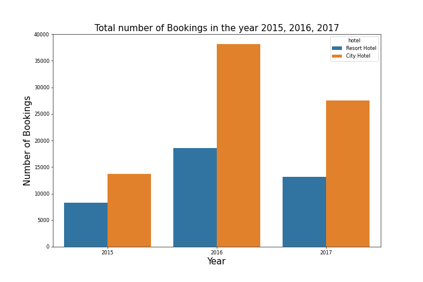

```python
plt.subplots(figsize=(12,8))
sns.countplot(x='arrival_date_year', hue='hotel',  data=hotel_df);
plt.title("Total number of Bookings in the year 2015, 2016, 2017", fontsize=18)
plt.xlabel("Year", fontsize=18)
plt.ylabel("Number of Bookings", fontsize=18)
plt.show()
```

Explaination: This graph depicts the number of bookings in city and resort hotels in the years 2015, 2016 and 2017. By this comparison, we can infer that in the year 2016, city hotel had the highest number of bookings while the least number of bookings was for resort hotel in the year 2015. On the whole, the year 2016 saw an increase in number of bookings for both types of hotels

# 4. Total number of Month-wise Booking

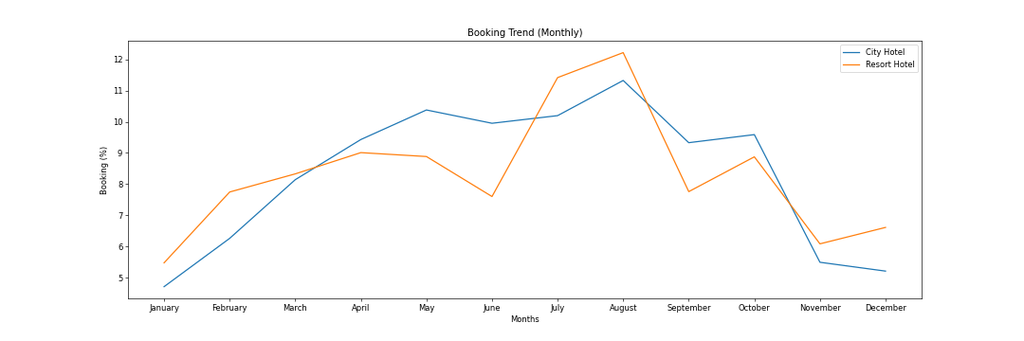

```python
## Order of months
new_order = ['January', 'February', 'March', 'April', 'May', 'June', 'July', 'August', 'September', 'October',
             'November', 'December']


## Select only City Hotel
sorted_months = hotel_df.loc[df.hotel=='City Hotel' ,'arrival_date_month'].value_counts().reindex(new_order)
x1 = sorted_months.index
y1 = sorted_months/sorted_months.sum()*100

## Select only Resort Hotel
sorted_months = hotel_df.loc[hotel_df.hotel=='Resort Hotel' ,'arrival_date_month'].value_counts().reindex(new_order)
x2 = sorted_months.index
y2 = sorted_months/sorted_months.sum()*100

## Draw the line plot
fig, ax = plt.subplots(figsize=(18,6))
ax.set_xlabel('Months')
ax.set_ylabel('Booking (%)')
ax.set_title('Booking Trend (Monthly)')
sns.lineplot(x1, y1.values, label='City Hotel', sort=False)
sns.lineplot(x1, y2.values, label='Resort Hotel', sort=False)
plt.show()
```

Explaination: This line-plot shows us the booking trend for city and resort hotel throughout the year. From this, we can notice that the bookings for both the hotels was the highest in the month of august i.e., towards the end of summer and the month that saw the least number of bookings was January.